# Cooking Data

Daniel Klotz, Johannes Wesemann, Mathew Herrnegger

6 Juli 2016

# 1 Introduction

Within **visCOS** “cooking data” is is used as a synonym for the process of transforming *raw data* into *cooked data*, that is data in the COSERO data.frame format. The *cooked data* can then be used for figures and other things. The package already provides a set of basic functions for that task that were useful for the applications at the institute.

This section defines these functions and explains their usage. Currently the following steps can be performed from within **visCOS**_

- Provide example data
- Remove junk
- Prepare date formats
- Define periods

**Examples:**

The function `get_cos_data_example` can be used to get some exemplary data from within **visCOS**:

```r
  library(visCOS)
  require(magrittr)
  options(width=80)
  runoff_example_raw <- get_cos_data_example()
  head(runoff_example_raw)
```

```
##   yyyy mm dd hh min QOBS_0001 QOSI_0001 QSIM_0001 QOBS_0002 QOSI_0002 QSIM_0002
## 1 2007  1  1  0   0      2.98      3.48      3.48      2.56      3.11      3.11
## 2 2007  1  1  1   0      2.89      3.48      3.48      2.56      3.11      3.11
## 3 2007  1  1  2   0      2.64      3.48      3.48      2.57      3.11      3.11
## 4 2007  1  1  3   0      2.51      3.48      3.48      2.57      3.11      3.11
## 5 2007  1  1  4   0      2.42      3.48      3.48      2.57      3.11      3.11
## 6 2007  1  1  5   0      2.34      3.49      3.49      2.57      3.11      3.11
```

The next step would be to adapt the options (`viscos_options`, but in this case the options are already set as in the data:

```r
   viscos_options() %>% unlist()
```

```
##         name_o         name_s      data_unit   name_COSyear  name_COSmonth
##         "qobs"         "qsim"      "(m^3/s)"         "yyyy"           "mm"
##    name_COSday   name_COShour    name_COSmin  name_COSposix name_COSperiod
##           "dd"           "hh"          "min"    "posixdate"       "period"
##   missing_data        color_o        color_s     of_limits1     of_limits2
##         "-999"    "steelblue"       "orange"            "0"            "1"
```

However, a glimpse of the data above shows that some of the columns (`QOSI_0001` and `QOSI_0002`) are not needed for the analysis. All the junk data, i.e. data columns that are not defined within the options and unobserved columns can be removed using the `remove_junk` function. Additionally **visCOS** needs to have two different ways to define the date of a given row (see: Introduction). In the runoff_example each part of the date definition is defined with a column: “yyyy” - year, “mm” - month, “hh” - hour, “min” - minute. The other needed format is the POSIXct`format (see: [link](https://stat.ethz.ch/R-manual/R-devel/library/base/html/as.POSIXlt.html)) format often used within R. Here all the information is saved within one column Given one date format is available in the data.frame the other can be generated by using`complete_dates`.

```r
  runoff_example_raw %>%
    remove_junk() %>%
    complete_dates() %>%
    head()
```

```
##   yyyy mm dd hh min QOBS_0001 QSIM_0001 QOBS_0002 QSIM_0002           posixdate
## 1 2007  1  1  0   0      2.98      3.48      2.56      3.11 2007-01-01 00:00:00
## 2 2007  1  1  1   0      2.89      3.48      2.56      3.11 2007-01-01 01:00:00
## 3 2007  1  1  2   0      2.64      3.48      2.57      3.11 2007-01-01 02:00:00
## 4 2007  1  1  3   0      2.51      3.48      2.57      3.11 2007-01-01 03:00:00
## 5 2007  1  1  4   0      2.42      3.48      2.57      3.11 2007-01-01 04:00:00
## 6 2007  1  1  5   0      2.34      3.49      2.57      3.11 2007-01-01 05:00:00
```

Lastly, if a seasonal or periodical analysis of the data wants to be done, these periods can be defined with the `mark_periods` function. In the example case, the hydrological years, going from September till August, will be defined:

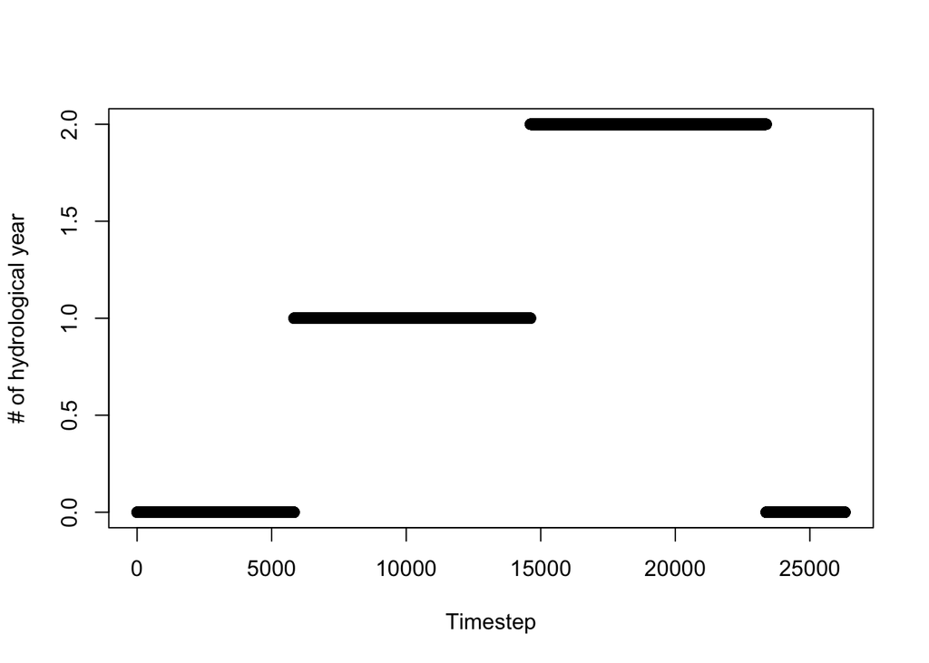

```r
  cooked_runoff_example <- runoff_example_raw %>%
    remove_junk() %>%
    complete_dates() %>%
    mark_periods(., start_month = 9, end_month = 8)
# here is an example plot to visualise the periods
  plot(cooked_runoff_example$period,
       xlab = "Timestep",
       ylab = "# of hydrological year")
```

# 2 Code

This function defines the data cooking functions.

## 2.1 `get_cos_data_example`

visCOS provides some exemplary data. All the available functions can be tested with it. `get_cos_data_example` is a small wrapper function to get the data from within the package via `read.csv`

**Note** at this stage, only a comparison between **numbered catchments** is possible for two parameters is possible. So the data must include an integer number after the description (like “QObs_001” and “QSim_001”)

```r
  #' Get runoff example
  #'
  #' Get exemplary runoff data to test the different functions of visCOS
  #' @export
  get_cos_data_example <- function() {
    file_path <- system.file("extdata",
                             "runoff_example.csv",
                             package = "visCOS")
    runoff_example <- read.csv(file_path)
    return(runoff_example)
  }
```

## 2.2 `remove_junk`

This function removes all columns not specified in the `viscos_options`, as well basins where no `data_o` is available. **Note** that the routine is **not** case sensitive. It does not distinguish between small and capital letters!

The first part of the code loads the dependencies and makes sure that the `cos_data` variable is a data.frame (see: chapter about *defensive coding*).

The body of `remove_junk` works as following: First, the names of the columns of the `cos_data` are determined and helper function `get_regex_for_cos_data` is invoked to get regular expressions for the columns defined within `viscos_otopns`. Then the `idx` of the different wanted data is extracted and used to select the appropriate columns.

Afterwards, the “sub” function `only_observed_basins` is being executed (see next chapter)

```r
  #' removes junk in cos_data
  #'
  #' Removes all columns which are not foreseen (see: viscos_options) from
  #' runoff data
  #'
  #' @import magrittr
  #' @param cos_data The cos_data data.frame (see vignette for info)
  #' @return data.frame object without the chunk
  #' @export
  remove_junk <- function(cos_data) {
    assert_dataframe(cos_data)
    #
    names_in_data <- cos_data %>% names
    regex_columns <- get_regex_for_cos_data() # see: helpers
    #
    idx <- regex_columns %>%
      grep(.,names_in_data, ignore.case = TRUE)
    no_junk_cos_data <- cos_data[ , idx]
    return( only_observed_basins(no_junk_cos_data) )
  }
```

### 2.2.1 `only_observed_basins`

This function removes basins for which no data in the `o_data` column. No observation are columns where all the entries are either as defined in `viscos_options("missing_data")` or `NA's`. At the end of the function the former are transformed into `NA's`.

```r
  # remove basins without observations
  #
  # Removes basins without observation (-999/NA values) from the provided data.frame
  #
  # @param cos_data A raw cos_data data.frame, which may contains basins
  # without observations.
  # \strong{Note:} It is assumed that all available basins are simulated!
  # @return data.frame without the observation-free basins
  #
  # @import magrittr
  # @import pasta
  only_observed_basins <- function(cos_data) {
    require("magrittr")
    require("pasta")
    assert_dataframe(cos_data)
    # set NA values to viscos_options("missing_data") and check if there are
    # cloumns wihtouth observervation
    chosen_cols <- which( names(cos_data) != viscos_options("name_COSposix") )
    rows_with_na <- is.na(cos_data[,chosen_cols])
    data_wihtouth_posix <- cos_data[ ,chosen_cols]
    data_wihtouth_posix[rows_with_na] <- viscos_options("missing_data")
    colmax <- sapply(X = data_wihtouth_posix, FUN = max)
    #
    # if there are columns withouth observations remove them from the data:
    if ( any(colmax < 0.0) ){
      name_o <- viscos_options("name_o")
      neg_obs_names <- which(colmax < 0.0) %>%
        names %>%
        grepl(name_o %.% "*",.,ignore.case = TRUE) %>%
        idx_temp[.]
      neg_s_names <- gsub(name_o,viscos_options("name_s"),neg_obs_names,ignore.case = TRUE )
      data_selection <- neg_obs_names %|% neg_s_names %>%
        grepl(., names(cos_data), ignore.case = TRUE) %>%
        not(.)
      data_only_observed <- cos_data[ ,data_selection]

    } else {
      data_only_observed <- cos_data
    }
    # set all missing data values to NA for use in hydroGOF
    idx_NA <- data_only_observed %>%
      equals(viscos_options("missing_data"))
    data_only_observed[idx_NA] <- NA
    return(data_only_observed)
  }
```

## 2.3 `complete_dates`

This function is not finished yet! Within cos_data data.frame (see: introduction) the date has to be defined in two formats: With 5 columns, where the columns are year-month-day-hour-minute and names as defined in `viscos_options()` and with one column in `POSIXct` format (see: [link](https://stat.ethz.ch/R-manual/R-devel/library/base/html/as.POSIXlt.html)), that is named as defined in `viscos_options("name_COSposix")`. The idea of the `complete_dates` fucntion is to provide a internal posibility to create the one format out of the ohter and thus *complete the dates*.

**However**, currently it is only possible to convert the 5-columns representation into `POSIXct` dates via the internally defined `implode_cosdate` function.

Also by using *UTC* a **fixed time-zone** is assumed within visCOS to avoid problems with leaps in time (summer/winter time).

```r
  #' Complete the date-formats with POSIXct or COSdate
  #'
  #' Complete the data-formats of your data.frame `POSIXct` and/or `COSdate`
  #'
  #' @param cos_data The data.frame, which contains the runoff information
  #' @param name_cosyear string with the name of the `COSdate` year column
  #' @param name_posix string with the name of the POSIXct column
  #' @return The new runoff data.frame with the added data-format.
  #'
  #' @import magrittr
  #'
  #' @export
complete_dates <- function(cos_data) {
  # make sure that magrittr is loaded:
  assert_dataframe(cos_data)
  # check for COSdates and stop if non-logical expression are obtained
  OK_COSdate <- any(
    unlist(viscos_options("name_COSyear",
                          "name_COSmonth",
                          "name_COSmonth",
                          "name_COShour",
                          "name_COSmin")
                           )
    %in%
    names(cos_data)
  )
  OK_POSIXdates <- any(names(cos_data) == viscos_options("name_COSposix"))
  if ( !is.logical(OK_COSdate) | !is.logical(OK_POSIXdates) ) {
    stop("Something is wrong :( \n
         some of the date-columns could not be processed!")
  }
  # choose function depending on which formats are available!
  if (!OK_COSdate & !OK_POSIXdates) {
    stop("Something is wrong :( \n
         The 5 cosero date columns and the POSIXct colum could not be found")
  } else if (OK_COSdate & !OK_POSIXdates) {
    cos_data <- implode_cosdate(cos_data) # see following chapter
  } else if (!OK_COSdate & OK_POSIXdates) {
    stop("POSIXct to COSdates not yet supported :(")
  }
  return(cos_data)
}
```

### 2.3.1 `implode_cosdate`

This function is used to transform the “old-school” 5 column format into the widely spread POSIXct format. The function is not exported and should only be called from within `complete_date()`!. Also, thanks to Christoph Schürz for his help with conception.

```r
implode_cosdate <- function(cos_data) {
  require("magrittr", quietly = TRUE)
  assert_dataframe(cos_data)
  name_string <-  cos_data %>% names %>% tolower
  #
  POSIXdate <- paste(cos_data[[viscos_options("name_COSyear")]],
                     sprintf("%02d",cos_data[[viscos_options("name_COSmonth")]]),
                     sprintf("%02d",cos_data[[viscos_options("name_COSday")]]),
                     sprintf("%02d",cos_data[[viscos_options("name_COShour")]]),
                     sprintf("%02d",cos_data[[viscos_options("name_COSmin")]]),
                     sep= "" ) %>%
    as.POSIXct(format = "%Y%m%d%H%M", origin = .[1], scale = "hourly", tz = "UTC")
  cos_data[[viscos_options("name_COSposix")]] <- POSIXdate
  return(cos_data)
}
```

## 2.4 `remove_leading_zeros`

This internal function removes leading zeros from column names of the `cos_data` data.frame. The function has no defensive code but uses `remove_junk` (see: above). It should therefore be used with care!

**Sad Note:** The current solution is bit suboptimal as many operations are needed and different tricks are used (e.g. `as.numeric %>% as.character`) to obtain the wanted result. We hope that better solutions can be found in the future.

```r
# remove leading zeros from the names of cos_data (data.frame)
remove_leading_zeros <- function(cos_data) {
  require("magrittr", quietly = TRUE)
  cos_data %<>% remove_junk
  #
  runoff_names <- cos_data %>% names
  runoff_lowercase_names <- runoff_names %>% tolower
  #
  separator <- runoff_lowercase_names %>%
    extract( grep(viscos_options()$name_o,.) ) %>%
    extract( 1 ) %>%
    gsub(viscos_options()$name_o,"",.) %>%
    gsub("\\d","",.)
  searchterm <- paste0(viscos_options()$name_o,"|", viscos_options()$name_s)
  runoff_nums <- runoff_lowercase_names %>%
    gsub(searchterm,"",.) %>%
    gsub(separator,"",.) %>%
    gsub("\\D","",.)
  searchterm <- paste(runoff_nums, collapse = "")
  runoff_only_names <- runoff_names %>%
    gsub(paste0("[",searchterm,"]"),"",.) %>%
    gsub(separator,"",.)
  runoff_new_numbers <- runoff_nums %>%
    as.numeric() %>%
    as.character()
  runoff_new_numbers[is.na(runoff_new_numbers)] <- ""
  #
  names(cos_data) <- runoff_new_numbers %>%
    gsub("\\d+",separator,.) %>%
    paste0(runoff_only_names,.,runoff_new_numbers)
  return(cos_data)
}
```

## 2.5 `mark_periods`

This function can be used to create a `viscos_options("name_COSperiod")`. The period column is a vector of increasing integer that is set to 0 for rows that are out of the period.

The current solution for defining this columns is not realy satisfying, but the problem seems to be non-trival… Life is short and it was the best that the authors could come out with so far.

In its current iteration the function takes `cos_data` and the two integers `start_month` and `end_month` as inputs, that can be used to define the to-be marked periods. The function can be directly used on raw data since the `remove_junk` and `complete_dates` are internaly applied to. This does however also mean that it needs to be used with care!

The computation is done in the following way: (I) Before starting the acutal marking the variable `period_range` and the `out_of_period` vector is defined. (II) With the help of the vectors the periods can be marked in two steps:

- First, all the starting months within cos_data are marked and the cumulative sum is used to count the periods within the data.frame. At the beginning of the first period, the counter is at “1” and becomes “2” with the beginning of the second period and so on.
- Secondly, the `out_of_period` of all years is set back to zero again by checking which months of the data are equal to the `out_of_period` entries.

There are at least two apparent problems with that solution:

- One problem is that the last year is not extracted properly if `start_month` > `end_month`. To compensate this problem the `dplyr` shenanigans are added at the end of the fucntion.
- The other problem is that that the first and last period are also included in the solution even if they are **not** complete!

```r
  #' calculate periods
  #'
  #' Mark the periods within cos_data.
  # The marking uses a monthly resolution, which are defined by the integers
  #' `start_month` and `end_month`.
  #'
  #' @param cos_data The data.frame, which contains the runoff information
  #' @return The runoff data.frame reduced and ordered according to the
  #' hydrological years within the data.
  #' \strong{Note:} The periods columns are formatted as characters!
  #'
  #' @import dplyr
  #' @import magrittr
  #'
  #' @export
mark_periods <- function(cos_data, start_month = 10, end_month = 9) {
  assert_dataframe(cos_data)
  cos_data %<>% remove_junk %>% complete_dates()
  # (I) get labels for the months
  if (start_month <= end_month ) {
    period_range <- seq(start_month,end_month)
    out_of_period <- seq(1,12) %>% extract( !(seq(1,12) %in% period_range) )
  } else if (start_month > end_month) {
    range_1 <- seq(start_month,12)
    range_2 <- seq(1,end_month)
    period_range <- c(range_1,range_2)
    out_of_period <- seq(1,12) %>% extract( !(seq(1,12) %in% period_range) )
  }

  # (II) mark periods:
    eval_diff <- function(a) {c(a[1],diff(a))}
    cos_data[[viscos_options("name_COSperiod")]] <-
      cos_data[[viscos_options("name_COSmonth")]] %in% c(start_month) %>%
      eval_diff %>%
      pmax(.,0) %>%
      cumsum
    cos_data$period[cos_data[[viscos_options("name_COSmonth")]] %in% out_of_period] <- 0
    # corrections for last year
    max_year <- max(cos_data[[viscos_options("name_COSyear")]])
    cos_data %<>% dplyr::mutate(
      period = ifelse(
        (  (.[[viscos_options("name_COSyear")]] == max_year) &
           (.[[viscos_options("name_COSmonth")]] > end_month)  ),
                      0,
                      period
        )
      )
    return(cos_data)
}
```

Here are two additonal examples that display the slected periods and the numbering:

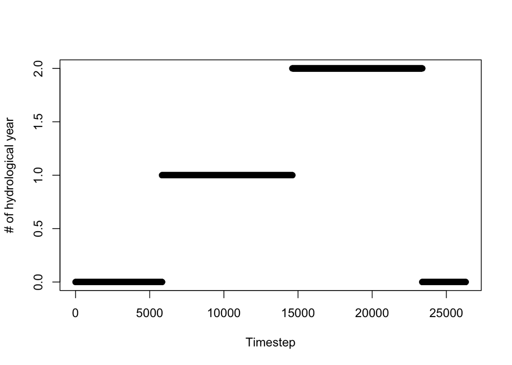

```r
require(magrittr)
require(visCOS)
# mark_periods example 1: Hydrological years (September till August)
# note that the last year is not complete, so the counter jumps back to 0
ex1 <- get_cos_data_example() %>% mark_periods(.,start_month = 9, end_month = 8)
plot(ex1$period, xlab="Timestep", ylab = "# of hydrological year")
```

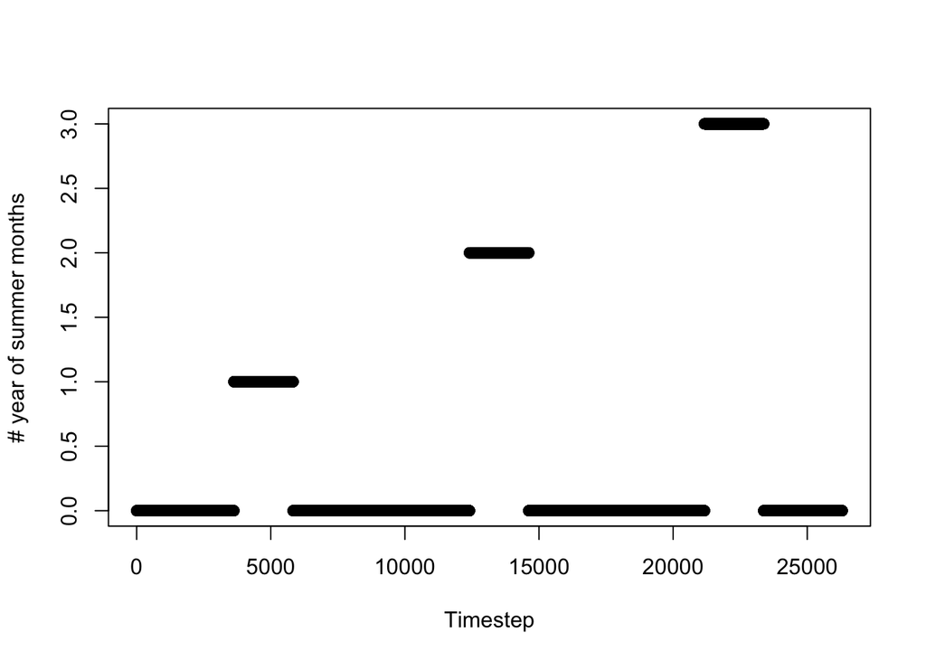

```r
# mark_periods example 2: Summer Months (June till August)
ex2 <- get_cos_data_example() %>% mark_periods(.,start_month = 6, end_month = 8)
plot(ex2$period, xlab="Timestep", ylab = "# year of summer months")
```

## 2.6 `cos_data_as_xts`

This function is actually just a small wrapper around the `xts::xts` function for the purposes of **visCOS**.

A notable quirk of the function is that the names of the header are put to lower cases via the `tolower` function and possible leading zeros in the enumeration of the basins are removed.

Currently it is not exported as users can use `xts` themselves perfectly well, and it is felt that the function does not provide enough added value for the user.

```r
  #' Convert cos_data to xts-format
  #'
  #' Converts the cos_data (class: data_frame) into an xts object
  #'
  #' @param cos_data data_frame of the cos_data (see: xxx)
  #' @return xts object of the cos_data data.frame
  #'
  #' @import zoo
  #' @importFrom xts xts
  #' @import magrittr
cos_data_as_xts <- function(cos_data) {
  # pre
  assert_dataframe(cos_data)
  assert_junk(cos_data)
  assert_complete_date(cos_data)
  # everything is set to lower case
  cos_data <- remove_leading_zeros(cos_data) %>%
    magrittr::set_names(names(cos_data) %>% tolower)
  name_posix <- viscos_options("name_COSposix") %>% tolower
  cos_data_as_xts <- xts(x = cos_data[], # ,names(cos_data) != name_posix
                            order.by = cos_data[[name_posix]])
  #
  return(cos_data_as_xts)
}
```